# Microbiome data analysis using DADA2

Dattatray S. Mongad[^1] and Nikeeta S. Chavan[^2]

28/04/2020

### 1. Preparation of data

```r
# Check/install and load dada2 package
if(!requireNamespace("dada2",quietly = T)){
  if(!requireNamespace("BiocManager",quietly = T)){
    install.packages("BiocManager")
  }
  BiocManager::install('dada2',version = '1.14.1')
}
library(dada2)
packageVersion('dada2')
```

```
## [1] '1.14.1'
```

```r
# Set working directory. All files generated will be stored at following path
# setwd('../data/dada2/')
# Store path of sequence data. If forward and reverse reads are at different locations please use pathF and pathR variables at subsequent steps
path <- 'MiSeq_SOP/'

# MiSeq SOP data filenames have format SAMPLENAME_R1_001.fastq and SAMPLENAME_R2_001.fastq
# Here we will make two vectors for storing list of absolute paths of forward and reverse files.
forward.files <- sort(list.files(path, pattern="_R1_001.fastq", full.names = TRUE))

reverse.files <- sort(list.files(path, pattern="_R2_001.fastq", full.names = TRUE))


# We can make a vector of sample names by extracting from filenames, assuming filenames have format: SAMPLENAME_XXX.fastq
sample.names <- sapply(strsplit(basename(forward.files), "_"), `[`, 1)
```

### 2. Sequence quality check

Every sequencing run can have unique quality profiles. Assuming that all samples in MiSeq SOP data are sequenced in single run, we can get snapshot of quality profiles all samples by inspecting 1 or 2 samples only. Following figures shows that quality profiles for forward and reverse reads starts dropping by 240 bp and 160 bp respectively.

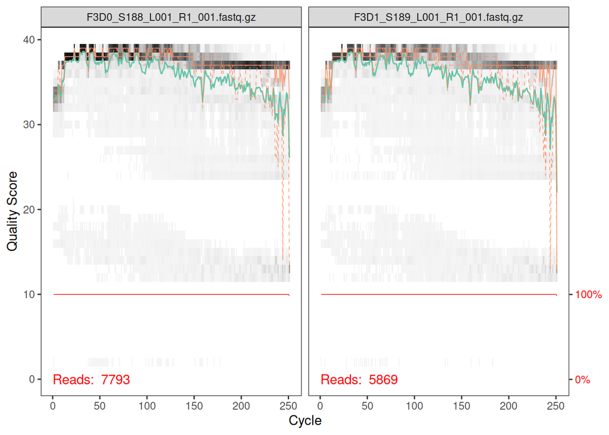

```r
plotQualityProfile(forward.files[1:2])
```

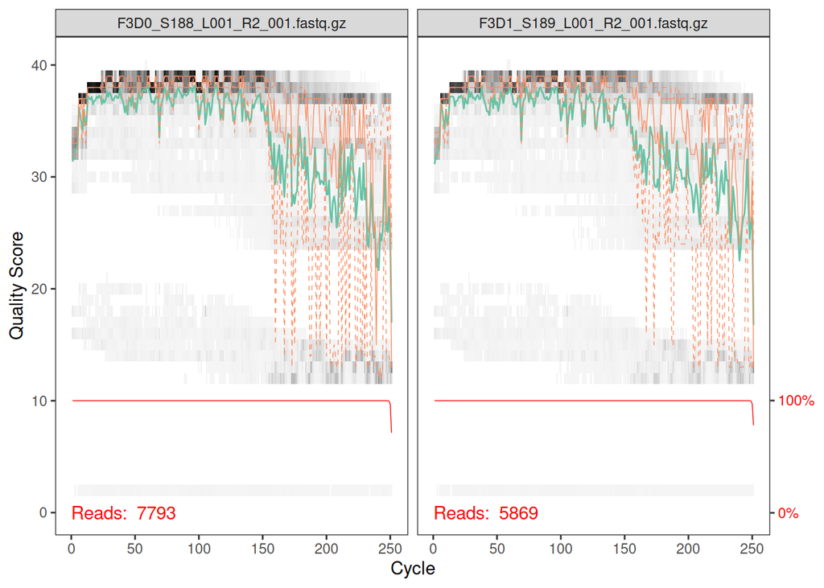

```r
plotQualityProfile(reverse.files[1:2])
```

### 3. Filtering and Trimming

*‘filterAndTrim’* function from DADA2 provides different ways to trim and filter reads. Following commands will truncate forward and reverse reads after 240 & 160 bp or at first instance where quality score is less than truncQ. This function will discard reads which have ‘N’ character or matches with phiX genome. As we are using 2X250 V4 sequencing data and length of V4 region of 16S rRNA gene is approximately 254 bp, the forward and reverse reads are almost overlapping. Hence, we need not to worry too much about trimming criteria. But, with less overlapping regions like V2-V4 or V3-V5, one must consider the length of overlapping region to merge these reads later.

```r
# Create folders to store the filtered reads
filt.forward <- file.path(path, "filteredF", paste0(sample.names, "_F_filt.fastq.gz"))
filt.reverse <- file.path(path, "filteredR", paste0(sample.names, "_R_filt.fastq.gz"))
names(filt.forward) <- sample.names
names(filt.reverse) <- sample.names

out <- filterAndTrim(forward.files, filt.forward, reverse.files,
      filt.reverse, truncLen=c(240,160), maxN=0, maxEE=c(2,2),
      truncQ=2, rm.phix=TRUE, compress=TRUE, multithread=TRUE)

head(out)
```

```
##                                  reads.in reads.out
## F3D0_S188_L001_R1_001.fastq.gz       7793      7113
## F3D1_S189_L001_R1_001.fastq.gz       5869      5299
## F3D141_S207_L001_R1_001.fastq.gz     5958      5463
## F3D142_S208_L001_R1_001.fastq.gz     3183      2914
## F3D143_S209_L001_R1_001.fastq.gz     3178      2941
## F3D144_S210_L001_R1_001.fastq.gz     4827      4312
```

### 4. Learning error rates

As every amplicon dataset/sequencing run has different error rates, the parametric error model has to build seperately on each dataset. DADA2 uses subset of reads from input data to build a model which quantifies the rate at which sequence(i) is produced from sequence(j) as a function of composition and quality values of sequences. This models keep estimating the errors until these estimates converges with observed error rates.

```r
errF <- learnErrors(filt.forward, multithread=TRUE)
```

```
## 33514080 total bases in 139642 reads from 20 samples will be used for learning the error rates.
```

```r
errR <- learnErrors(filt.reverse, multithread=TRUE)
```

```
## 22342720 total bases in 139642 reads from 20 samples will be used for learning the error rates.
```

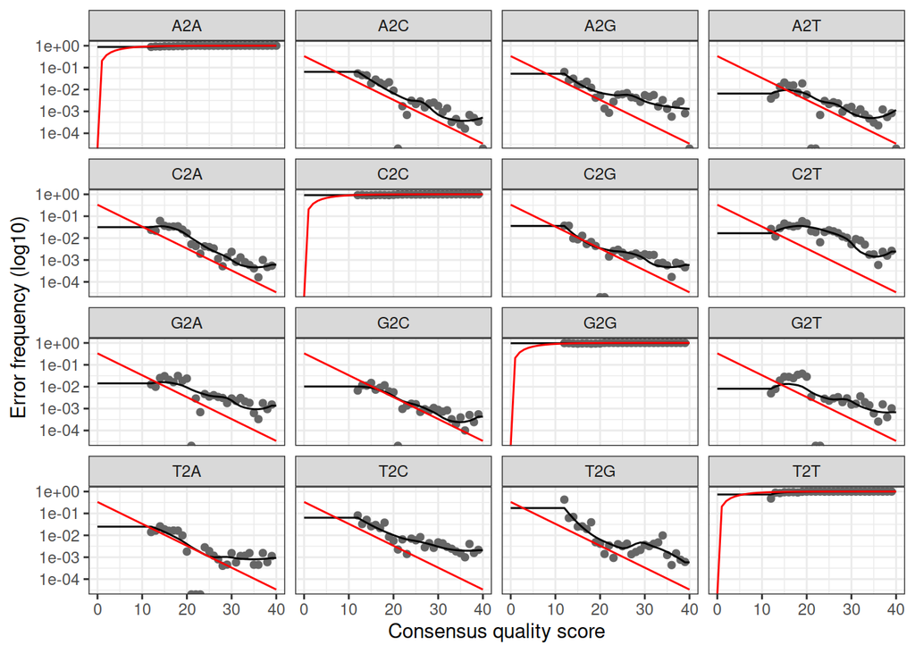

```r
# plot error model (here forward plot is shown only)
plotErrors(errF, nominalQ=TRUE)
```

Above error model shows estimated and observed error for forward reads. The black line represents estimated error rates which converges with observed error rate (black points) for all possible 16 transitions. With increase in quality scores the error frequency also drops, this shows that the error model is good fit and we can proceed with confidence.

### 5. Sample inference

The *‘dada’* functions applies the core *‘Divisive Amplicon Denoising Algorithm’* on forward and reverse reads separately using learned error model. This step does depreplication (picking unique sequences) and then run divisive partitioning algorithm which starts by placing all unique sequences in single partition and depending on calculated abundance p-value (if <user cut-off), a new partition is formed with new unique sequences. Basically, this step tries to identify the variants in sequences and classify them in different partitions after corrections. This step is carried out in iterative manner for each sample until no new partition of sequences is possible.

```r
dadaFs <- dada(filt.forward, err=errF, multithread=TRUE)
```

```
## Sample 1 - 7113 reads in 1979 unique sequences.
## Sample 2 - 5299 reads in 1639 unique sequences.
## Sample 3 - 5463 reads in 1477 unique sequences.
## Sample 4 - 2914 reads in 904 unique sequences.
## Sample 5 - 2941 reads in 939 unique sequences.
## Sample 6 - 4312 reads in 1267 unique sequences.
## Sample 7 - 6741 reads in 1756 unique sequences.
## Sample 8 - 4560 reads in 1438 unique sequences.
## Sample 9 - 15637 reads in 3590 unique sequences.
## Sample 10 - 11413 reads in 2762 unique sequences.
## Sample 11 - 12017 reads in 3021 unique sequences.
## Sample 12 - 5032 reads in 1566 unique sequences.
## Sample 13 - 18075 reads in 3707 unique sequences.
## Sample 14 - 6250 reads in 1479 unique sequences.
## Sample 15 - 4052 reads in 1195 unique sequences.
## Sample 16 - 7369 reads in 1832 unique sequences.
## Sample 17 - 4765 reads in 1183 unique sequences.
## Sample 18 - 4871 reads in 1382 unique sequences.
## Sample 19 - 6504 reads in 1709 unique sequences.
## Sample 20 - 4314 reads in 897 unique sequences.
```

```r
dadaRs <- dada(filt.reverse, err=errR, multithread=TRUE)
```

```
## Sample 1 - 7113 reads in 1660 unique sequences.
## Sample 2 - 5299 reads in 1349 unique sequences.
## Sample 3 - 5463 reads in 1335 unique sequences.
## Sample 4 - 2914 reads in 853 unique sequences.
## Sample 5 - 2941 reads in 880 unique sequences.
## Sample 6 - 4312 reads in 1286 unique sequences.
## Sample 7 - 6741 reads in 1803 unique sequences.
## Sample 8 - 4560 reads in 1265 unique sequences.
## Sample 9 - 15637 reads in 3414 unique sequences.
## Sample 10 - 11413 reads in 2522 unique sequences.
## Sample 11 - 12017 reads in 2771 unique sequences.
## Sample 12 - 5032 reads in 1415 unique sequences.
## Sample 13 - 18075 reads in 3290 unique sequences.
## Sample 14 - 6250 reads in 1390 unique sequences.
## Sample 15 - 4052 reads in 1134 unique sequences.
## Sample 16 - 7369 reads in 1635 unique sequences.
## Sample 17 - 4765 reads in 1084 unique sequences.
## Sample 18 - 4871 reads in 1161 unique sequences.
## Sample 19 - 6504 reads in 1502 unique sequences.
## Sample 20 - 4314 reads in 732 unique sequences.
```

```r
dadaFs[[1]]
```

```
## dada-class: object describing DADA2 denoising results
## 128 sequence variants were inferred from 1979 input unique sequences.
## Key parameters: OMEGA_A = 1e-40, OMEGA_C = 1e-40, BAND_SIZE = 16
```

### 6. Merging paired-end reads

*‘mergePairs’* aligns forward and reverse sequences using global ends-free alignment and merge them if two sequences overlaps perfectly. The number of mismatch and overlap length can be adjusted using *‘maxMismatch’* and *‘minOverlap’* arguments which have default values of 0 & 20. Again, as this was 2X250 V4 sequencing data, the overlap length can be high as 148 (see *‘nmatch’* column in following output).

```r
mergers <- mergePairs(dadaFs, filt.forward, dadaRs, filt.reverse, verbose=TRUE)
```

```
## 6540 paired-reads (in 107 unique pairings) successfully merged out of 6891 (in 197 pairings) input.
```

```
## 5028 paired-reads (in 101 unique pairings) successfully merged out of 5190 (in 157 pairings) input.
```

```
## 4986 paired-reads (in 81 unique pairings) successfully merged out of 5267 (in 166 pairings) input.
```

```
## 2595 paired-reads (in 52 unique pairings) successfully merged out of 2754 (in 108 pairings) input.
```

```
## 2552 paired-reads (in 60 unique pairings) successfully merged out of 2784 (in 119 pairings) input.
```

```
## 3627 paired-reads (in 54 unique pairings) successfully merged out of 4109 (in 156 pairings) input.
```

```
## 6079 paired-reads (in 81 unique pairings) successfully merged out of 6514 (in 198 pairings) input.
```

```
## 3968 paired-reads (in 91 unique pairings) successfully merged out of 4388 (in 187 pairings) input.
```

```
## 14231 paired-reads (in 143 unique pairings) successfully merged out of 15355 (in 353 pairings) input.
```

```
## 10529 paired-reads (in 120 unique pairings) successfully merged out of 11165 (in 277 pairings) input.
```

```
## 11154 paired-reads (in 137 unique pairings) successfully merged out of 11797 (in 298 pairings) input.
```

```
## 4349 paired-reads (in 85 unique pairings) successfully merged out of 4802 (in 179 pairings) input.
```

```
## 17431 paired-reads (in 153 unique pairings) successfully merged out of 17812 (in 272 pairings) input.
```

```
## 5853 paired-reads (in 81 unique pairings) successfully merged out of 6099 (in 160 pairings) input.
```

```
## 3716 paired-reads (in 86 unique pairings) successfully merged out of 3894 (in 147 pairings) input.
```

```
## 6865 paired-reads (in 99 unique pairings) successfully merged out of 7191 (in 187 pairings) input.
```

```
## 4428 paired-reads (in 68 unique pairings) successfully merged out of 4605 (in 128 pairings) input.
```

```
## 4576 paired-reads (in 101 unique pairings) successfully merged out of 4739 (in 174 pairings) input.
```

```
## 6092 paired-reads (in 109 unique pairings) successfully merged out of 6315 (in 173 pairings) input.
```

```
## 4269 paired-reads (in 20 unique pairings) successfully merged out of 4281 (in 28 pairings) input.
```

```r
# Inspect the merger data.frame from the first sample
head(mergers[[1]])
```

```
##                                                                                                                                                                                                                                                       sequence
## 1 TACGGAGGATGCGAGCGTTATCCGGATTTATTGGGTTTAAAGGGTGCGCAGGCGGAAGAT…
## 2 TACGGAGGATGCGAGCGTTATCCGGATTTATTGGGTTTAAAGGGTGCGTAGGCGGCCTGC…
## 3 TACGGAGGATGCGAGCGTTATCCGGATTTATTGGGTTTAAAGGGTGCGTAGGCGGGCTGT…
## 4 TACGGAGGATGCGAGCGTTATCCGGATTTATTGGGTTTAAAGGGTGCGTAGGCGGGCTTT…
## 5 TACGGAGGATGCGAGCGTTATCCGGATTTATTGGGTTTAAAGGGTGCGCAGGCGGACTCT…
## 6 TACGGAGGATGCGAGCGTTATCCGGATTTATTGGGTTTAAAGGGTGCGTAGGCGGGATGC…
##   abundance forward reverse nmatch nmismatch nindel prefer accept
## 1       579       1       1    148         0      0      1   TRUE
## 2       470       2       2    148         0      0      2   TRUE
## 3       449       3       4    148         0      0      1   TRUE
## 4       430       4       3    148         0      0      2   TRUE
## 5       345       5       6    148         0      0      1   TRUE
## 6       282       6       5    148         0      0      2   TRUE
```

### 7. Construct sequence table and remove chimeras

The sequence table is just the abundance matrix with rows as samples and columns as ASV sequences. Here, we got 293 ASV sequences in total 20 samples. DADA2 uses denovo method to identify chimeras by performing Needleman and Wunsch global alignment of each sequences with all more abundant sequences to find the combination of left and right parent of child sequences without any mismatch.

```r
seqtab <- makeSequenceTable(mergers)
dim(seqtab)
```

```
## [1]  20 293
```

```r
seqtab.nochim <- removeBimeraDenovo(seqtab, method="consensus", multithread=TRUE, verbose=TRUE)
```

```
## Identified 61 bimeras out of 293 input sequences.
```

```r
dim(seqtab.nochim)
```

```
## [1]  20 232
```

```r
sum(seqtab.nochim)/sum(seqtab)
```

```
## [1] 0.964064
```

### 8. Assign taxonomy

```r
taxa <- assignTaxonomy(seqtab.nochim, "silva_nr_v138_train_set.fa.gz", multithread=TRUE)

taxa <- addSpecies(taxa, "silva_species_assignment_v138.fa.gz")
```

### 9. Build phyloseq object

Now, we will construct phyloseq object using variable seqtab, taxa and sample metadata file (*map.tsv*). We have constructed Neighbor-joining tree using phangorn R package (Schliep 2011)` and then fit a GTR+G+I (Generalized time-reversible with Gamma rate variation) maximum likelihood tree.

```r
if(!requireNamespace("phyloseq",quietly = T)){
  if(!requireNamespace("BiocManager",quietly = T)){
    install.packages("BiocManager")
  }
  BiocManager::install('phyloseq',version = '1.30.0')
}
library(phyloseq)
packageVersion('phyloseq')
```

```
## [1] '1.30.0'
```

```r
# read sample metadata
samdf <- read.table(file = 'map.tsv',header = T,sep = '\t',row.names = 1)
ps <- phyloseq(otu_table(seqtab.nochim, taxa_are_rows=FALSE),
               sample_data(samdf),
               tax_table(taxa))
# Remove mock sample
ps <- prune_samples(sample_names(ps) != "Mock", ps)

# Add ASV sequences in refseq slot
dna <- Biostrings::DNAStringSet(taxa_names(ps))
names(dna) <- taxa_names(ps)
ps <- merge_phyloseq(ps, dna)
ps
```

```
## phyloseq-class experiment-level object
## otu_table()   OTU Table:         [ 232 taxa and 19 samples ]
## sample_data() Sample Data:       [ 19 samples by 2 sample variables ]
## tax_table()   Taxonomy Table:    [ 232 taxa by 7 taxonomic ranks ]
## refseq()      DNAStringSet:      [ 232 reference sequences ]
```

```r
# Create phylogenetic tree by aligning ASV sequences
library(DECIPHER)
library(phangorn)
seqs <- getSequences(seqtab)
names(seqs) <- seqs # This propagates to the tip labels of the tree
alignment <- AlignSeqs(DNAStringSet(seqs), anchor=NA)
```

```
## Determining distance matrix based on shared 8-mers:
## ================================================================================
##
## Time difference of 0.61 secs
##
## Clustering into groups by similarity:
## ================================================================================
##
## Time difference of 0.12 secs
##
## Aligning Sequences:
## ================================================================================
##
## Time difference of 2.94 secs
##
## Iteration 1 of 2:
##
## Determining distance matrix based on alignment:
## ================================================================================
##
## Time difference of 0.05 secs
##
## Reclustering into groups by similarity:
## ================================================================================
##
## Time difference of 0.1 secs
##
## Realigning Sequences:
## ================================================================================
##
## Time difference of 1.48 secs
##
## Iteration 2 of 2:
##
## Determining distance matrix based on alignment:
## ================================================================================
##
## Time difference of 0.05 secs
##
## Reclustering into groups by similarity:
## ================================================================================
##
## Time difference of 0.1 secs
##
## Realigning Sequences:
## ================================================================================
##
## Time difference of 0.18 secs
```

```r
phang.align <- phyDat(as(alignment, "matrix"), type="DNA")
dm <- dist.ml(phang.align)
treeNJ <- NJ(dm) # Note, tip order != sequence order
fit = pml(treeNJ, data=phang.align)
```

```
## negative edges length changed to 0!
```

```r
## negative edges length changed to 0!

fitGTR <- update(fit, k=4, inv=0.2)
fitGTR <- optim.pml(fitGTR, model="GTR", optInv=TRUE, optGamma=TRUE,
                      rearrangement = "stochastic", control = pml.control(trace = 0))
detach("package:phangorn", unload=TRUE)

# add tree to phyloseq object
phy_tree(ps) <- fitGTR$tree
ps
```

```
## phyloseq-class experiment-level object
## otu_table()   OTU Table:         [ 232 taxa and 19 samples ]
## sample_data() Sample Data:       [ 19 samples by 2 sample variables ]
## tax_table()   Taxonomy Table:    [ 232 taxa by 7 taxonomic ranks ]
## phy_tree()    Phylogenetic Tree: [ 232 tips and 230 internal nodes ]
## refseq()      DNAStringSet:      [ 232 reference sequences ]
```

```r
# change ASV names and save phyloseq object
taxa_names(ps) <- paste0("ASV", seq(ntaxa(ps)))
saveRDS(ps,file = 'ps_dada2.rds')
```

### 10. Downstream analysis

We have carried out downstream analysis using phyloseq object from QIIME1 and DADA2 simultaneously. Please check https://microdm.github.io/downstream_analysis.html.

### References

Schliep, Klaus Peter. 2011. “phangorn: phylogenetic analysis in R.” *BIOINFORMATICS APPLICATIONS NOTE* 27 (4): 592–93. https://doi.org/10.1093/bioinformatics/btq706.

[^1]: National Centre for Cell Science, dattatray.mongad@nccs.res.in
[^2]: National Centre for Cell Science, chavannikitas94@gmail.com